# 在Mac OS上使用R Markdown生成含有中文的pdf文件

# 准备工作

除了安装R, RStudio外，还要安装[pandoc](http://pandoc.org/installing.html)和[BasicTeX](https://tug.org/mactex/). 如果电脑硬盘空间够大，可以直接安装[MacTex](https://tug.org/mactex/). 最后安装R软件包rticles. pandoc 和 BasicTex下载后双击运行安装。BsicTex 安装好后先升级一下，再安装ctex包，具体操作如下：

```
sudo tlmgr update --self
sudo tlmgr update --all
sudo tlmgr install ctex
```

如果运行中提示“package.sty” 缺失的话，直接用“sudo tlmgr install package”安装即可（package 为具体的软件包的名字）。打开RStudio安装rticles:

```
install.packages("rticles")
```

安装完成后，新建RMarkdown文件，在弹出窗口点击左下角“from template”，在右半边窗口选“CTex Documents”即可。

以下的内容为模版的默认内容的删减版。

# 引言

中文LaTeX文档并非难题。当然这句话得站在巨人 [CTeX](http://ctex.org) 的肩膀上才能说，它让我们只需要一句

```latex
\documentclass{ctexart} % 或者ctexrep/ctexbook
```

或者

```latex
\usepackage{ctex}
```

就轻松搞定中文LaTeX排版问题。跨平台通用的LaTeX编译却是个小难题，主要是没有一种跨平台通用且免费的中文字体。好吧，你们Windows用户永远有宋体黑体，你们Mac用户有华文字体，而我们苦逼Linux用户在编译LaTeX文档就没那么简单了[^1]，是啊，我们有文泉驿，但我们要是用了文泉驿之后把文档发给你们八成不能编译，因为你们没有安装文泉驿。

# 字体和选项

LaTeX包[**ctex**](http://ctan.org/pkg/ctex)支持若干种字体选项，如果你是**ctex**老用户，请注意这里我们要求的最低版本是2.2，你可能需要升级你的LaTeX包。从版本2.0开始，**ctex**支持根据不同操作系统自动选择中文字体，简直是为人类进步作出了巨大贡献，我们再也不必费尽口舌向用户解释“啊，你用Windows啊，那么你该使用什么字体；啊，你用Mac啊，又该如何如何”。

下面的YAML元数据应该能满足多数用户的需求，主要设置两项参数：文档类为`ctexart`（当然也可以是别的类），输出格式为`rticles::ctex`，其默认LaTeX引擎为XeLaTeX（真的，别纠结你的旧爱PDFLaTeX了）。

```yaml
---
documentclass: ctexart
output: rticles::ctex
---
```

# R代码段

R代码用R Markdown的语法嵌入，即三个反引号开始一段代码`` ```{r} ``和三个反引号`` ``` `` 结束一段代码：

```r
options(digits = 4)
fit = lm(dist ~ speed, data = cars)
coef(summary(fit))
```

```
##             Estimate Std. Error t value  Pr(>|t|)
## (Intercept)  -17.579     6.7584  -2.601 1.232e-02
## speed          3.932     0.4155   9.464 1.490e-12
```

```r
b = coef(fit)
```

上面回归方程中的斜率是3.9324，完整的回归方程为：
$$Y = -17.5791 + 3.9324x$$

画图当然也是木有问题的啦，想画就说嘛，不说我怎么知道你想画呢？

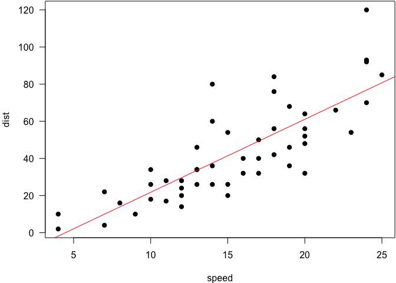

cars数据散点图以及回归直线。

```r
par(mar = c(4, 4, .1, .1), las = 1)
plot(cars, pch = 19)
abline(fit, col = 'red')
```

请不要问我为什么图浮动到下一页去了，这么初级的LaTeX问题问出来信不信我扁你。

# 小结

事实证明我们可以理直气壮地通过XeLaTeX将中文R Markdown转化为PDF文档，麻麻再也不用担心我的论文满屏幕都是反斜杠，朕养完小白鼠之后终于不必先折腾三个小时LaTeX再开始写实验报告了：打开RStudio，菜单File > New File > R Markdown，然后从模板中选择CTeX Documents，搞定。

[^1]: 切，傲娇的Linux用户怎么会干出找你们复制字体的事情

R Markdown转化为PDF文档的效果如下（只显示了第一页）

[figure not shown]